# AHP(visekriterijsko)

AntonioLabinjan

2025-01-14

Napomena: Evaluacija kriterija je subjektivna i nije garantirano da je kolegij koji je najbolji izbor za mene najbolji izbor za svih.

Pri upisu prve godine diplomskog studija na FIPU potrebno je odabrati izborni kolegij za svaki semestar. Na prvom semestru ponuđeni su sljedeći kolegiji: Blockchain aplikacije Robotika Interakcija čovjeka i računala

Svaki kolegij nosi točno 5 ECTS bodova, no razlikuju se po više faktora. Potrebno je ustvrditi kriterije po kojima će se odabrati neki od ponuđenih kolegija. Studenti mogu pokušati pronaći optimalan odabir na temelju sljedećih kriterija. Želimo da kolegij bude: Koristan i da znanje stečeno na njemu moguće je primijeniti u kasnijoj karijeri (i zaraditi na njemu :) ). Zanimljiv te da je njegovo gradivo moderno, aktualno i “up to date” sa trenutnom potražnjom na tržištu. Poželjno je da profesor/ica koji/a predaje bude normalan/normalna i ne komplicira život pretjerano. Od mogućih kombinacija načina polaganja preferira se polaganje isključivo preko projekta dok su moguće i varijante poput usmenog ispita, pismenog ispita i projekta, usmenog i pismenog ispita. Pošto se radi o izbornom predmetu, nije poželjno da bude pretjerano kompliciran i težak. Poželjno je da se predavanja i vježbe izvode u relativno podnošljivom terminu, a ne u kasnim popodnevnim/večernjim satima kad se gotovo nemoguće koncentrirati. U obzir se uzimaju i preporuke starijih kolega koji su već odslušali kolegije te imaju iskustva s njima.

No, nisu svi kriteriji jednako važni.

Kriteriji su: 1) Korisnost 2) Zanimljivost 3) Profesor/ica 4) Način polaganja (projektno/ispitno) 5) Težina 6) Vrijeme izvođenja (doba dana) 7) Preporuke kolega

```r
install.packages(c("Matrix", "knitr", "dplyr"))
library(Matrix)
library(knitr)
library(dplyr)
kriteriji <- c("Korisnost", "Zanimljivost", "Profesor/ica", "Način polaganja", "Težina", "Vrijeme izvođenja", "Preporuke kolega")
alternative <- c("Blockchain aplikacije", "Robotika", "HCI")

print(kriteriji)
```

```
## [1] "Korisnost"         "Zanimljivost"      "Profesor/ica"
## [4] "Način polaganja"   "Težina"            "Vrijeme izvođenja"
## [7] "Preporuke kolega"
```

Detaljnija evalucija kriterija: Bitnije je da je koristan nego zanimljiv Jednako je bitno da je koristan kao koji profesor ga predaje Bitnije je da je koristan nego kako se polaže Bitnije je da je koristan nego koliko je težak Bitnije je da je koristan nego kada se izvodi Bitnije je da je koristan nego što kolege preporučaju

Manje je bitno da je zanimljiv nego da je koristan Bitnije je da je zanimljiv nego koji profesor ga predaje Bitnije je da je zanimljiv nego kako se polaže Bitnije je da je zanimljiv nego koliko je težak Bitnije je da je zanimljiv nego kada se izvodi Bitnije je da je zanimljiv nego što kolege preporučaju

Manje je bitno kako se polaže nego koliko je koristan Manje je bitno kako se polaže nego koliko je zanimljiv Manje je bitno kako se polaže nego koji profesor ga predaje Bitnije je kako se polaže nego koliko je težak Bitnije je kako se polaže nego kada se izvodi Bitnije je kako se polaže nego što kolege preporučaju

Manje je bitno kada se izvodi nego koliko je koristan Manje je bitno kada se izvodi nego koliko je zanimljiv Manje je bitno kada se izvodi nego koji ga profesor predaje Manje je bitno kada se izvodi nego kako se polaže Manje je bitno kada se izvodi nego koliko je težak Bitnije je kada se izvodi nego koliko što kolege preporučaju

Manje je bitno što kolege preporučaju nego koliko je koristan Manje je bitno što kolege preporučaju nego koliko je zanimljiv Manje je bitno što kolege preporučaju nego koji ga profesor predaje Manje je bitno što kolege preporučaju nego kako se polaže Manje je bitno što kolege preporučaju nego koliko je težak Manje je bitno što kolege preporučaju nego kada se izvodi

Korisnost: 0.33856732 Zanimljivost: 0.25911882 Profesor/ica: 0.19563052 Način polaganja: 0.08962014 Težina: 0.06004118 Vrijeme izvođenja: 0.04185208 Preporuke kolega: 0.01516996

Numerički odnos kriterija za svaki kolegij definiran je na slijedeći način:

korisnost Blockchain Robotika HCI Blockchain 1 6 9 Robotika 1/6 1 9 HCI 1/9 1/9 1

zanimljivost Blockchain Robotika HCI Blockchain 1 1 8 Robotika 1 1 9 HCI 1/8 1/9 1

profesor/ica Blockchain Robotika HCI Blockchain 1 1 9 Robotika 1 1 9 HCI 1/9 1/9 1

način polaganja Blockchain Robotika HCI Blockchain 1 7 9 Robotika 1/7 1 8 HCI 1/9 1/8 1

težina Blockchain Robotika HCI Blockchain 1 8 9 Robotika 1/8 1 9 HCI 1/9 1/8 1

vrijeme izvođenja Blockchain Robotika HCI Blockchain 1 1 1 Robotika 1 1 1 HCI 1 1 1

Preporuke kolega Blockchain Robotika HCI Blockchain 1 6 9 Robotika 1/6 1 9 HCI 1/9 1/9 1

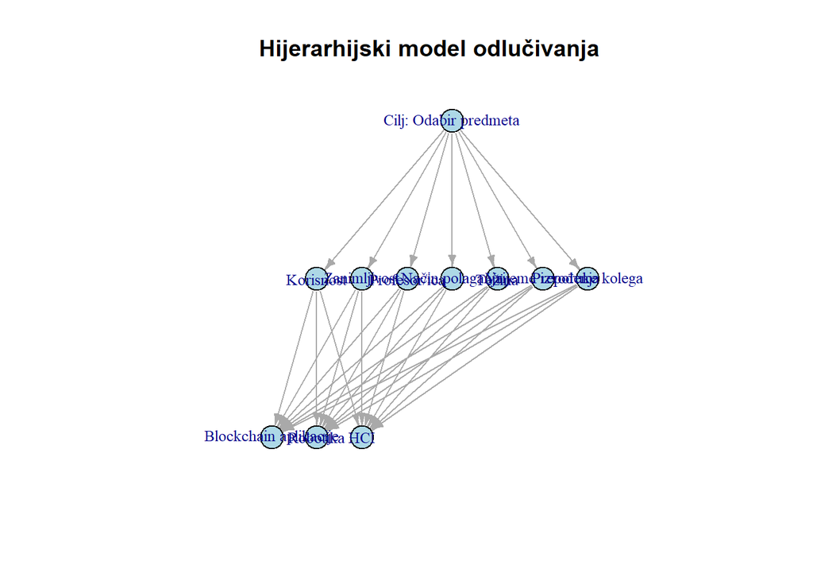

```r
if (!requireNamespace("igraph", quietly = TRUE)) {
  install.packages("igraph")
}

library(igraph)

nodes <- c("Cilj: Odabir predmeta",
           "Korisnost", "Zanimljivost", "Profesor/ica",
           "Način polaganja", "Težina", "Vrijeme izvođenja", "Preporuke kolega",
           "Blockchain aplikacije", "Robotika", "HCI")

edges <- data.frame(from = c("Cilj: Odabir predmeta", "Cilj: Odabir predmeta", "Cilj: Odabir predmeta",
                             "Cilj: Odabir predmeta", "Cilj: Odabir predmeta", "Cilj: Odabir predmeta",
                             "Cilj: Odabir predmeta",
                             "Korisnost", "Korisnost", "Korisnost",
                             "Zanimljivost", "Zanimljivost", "Zanimljivost",
                             "Profesor/ica", "Profesor/ica", "Profesor/ica",
                             "Način polaganja", "Način polaganja", "Način polaganja",
                             "Težina", "Težina", "Težina",
                             "Vrijeme izvođenja", "Vrijeme izvođenja", "Vrijeme izvođenja",
                             "Preporuke kolega", "Preporuke kolega", "Preporuke kolega"),
                    to = c("Korisnost", "Zanimljivost", "Profesor/ica",
                           "Način polaganja", "Težina", "Vrijeme izvođenja", "Preporuke kolega",
                           "Blockchain aplikacije", "Robotika", "HCI",
                           "Blockchain aplikacije", "Robotika", "HCI",
                           "Blockchain aplikacije", "Robotika", "HCI",
                           "Blockchain aplikacije", "Robotika", "HCI",
                           "Blockchain aplikacije", "Robotika", "HCI",
                           "Blockchain aplikacije", "Robotika", "HCI",
                           "Blockchain aplikacije", "Robotika", "HCI"))


g <- graph_from_data_frame(edges, vertices = nodes, directed = TRUE)

plot(g,
     layout = layout_as_tree(g, root = "Cilj: Odabir predmeta"),
     vertex.size = 15,
     vertex.color = "lightblue",
     vertex.label.cex = 0.8,
     edge.arrow.size = 0.5,
     main = "Hijerarhijski model odlučivanja")
```

```r
install.packages(c("Matrix", "knitr", "dplyr"))
library(Matrix)
library(knitr)
library(dplyr)


kriteriji <- c("Korisnost", "Zanimljivost", "Profesor/ica", "Način polaganja", "Težina", "Vrijeme izvođenja", "Preporuke kolega")
alternative <- c("Blockchain aplikacije", "Robotika", "HCI")

print(kriteriji)
```

```
## [1] "Korisnost"         "Zanimljivost"      "Profesor/ica"
## [4] "Način polaganja"   "Težina"            "Vrijeme izvođenja"
## [7] "Preporuke kolega"
```

```r
#Definirane su matrice kriterija te matrica za svaki kriterij posebno
matrica_kriterija <- matrix(c(1, 7, 1, 9, 9, 7, 9,
                              1/7, 1, 4, 7, 9, 10, 9,
                              1, 1/4, 1, 8, 3, 8, 8,
                              1/9, 1/7, 1/8, 1, 8, 3, 8,
                              1/9, 1/9, 1/3, 1/8, 1, 4, 8,
                              1/7, 1/10, 1/8, 1/3, 1/4, 1, 8,
                              1/9, 1/9, 1/8, 1/8, 1/8, 1/8, 1),
                            ncol = 7, byrow = TRUE)

matrica_korisnost <- matrix(c(1, 6, 9,
                              1/6, 1, 9,
                              1/9, 1/9, 1),
                            ncol = 3, byrow = TRUE)

matrica_zanimljivost <- matrix(c(1, 1, 8,
                                 1, 1, 9,
                                 1/8, 1/9, 1),
                               ncol = 3, byrow = TRUE)

matrica_profesor <- matrix(c(1, 1, 9,
                             1, 1, 9,
                             1/9, 1/9, 1),
                           ncol = 3, byrow = TRUE)

matrica_nacin_polaganja <- matrix(c(1, 7, 9,
                                    1/7, 1, 8,
                                    1/9, 1/8, 1),
                                  ncol = 3, byrow = TRUE)

matrica_tezina <- matrix(c(1, 8, 9,
                           1/8, 1, 9,
                           1/9, 1/8, 1),
                         ncol = 3, byrow = TRUE)

matrica_vrijeme <- matrix(c(1, 1, 1,
                            1, 1, 1,
                            1, 1, 1),
                          ncol = 3, byrow = TRUE)

matrica_preporuke <- matrix(c(1, 6, 9,
                              1/6, 1, 9,
                              1/9, 1/9, 1),
                            ncol = 3, byrow = TRUE)

print(matrica_kriterija)
```

```
##           [,1]      [,2]      [,3]      [,4]  [,5]   [,6] [,7]
## [1,] 1.0000000 7.0000000 1.0000000 9.0000000 9.000  7.000    9
## [2,] 0.1428571 1.0000000 4.0000000 7.0000000 9.000 10.000    9
## [3,] 1.0000000 0.2500000 1.0000000 8.0000000 3.000  8.000    8
## [4,] 0.1111111 0.1428571 0.1250000 1.0000000 8.000  3.000    8
## [5,] 0.1111111 0.1111111 0.3333333 0.1250000 1.000  4.000    8
## [6,] 0.1428571 0.1000000 0.1250000 0.3333333 0.250  1.000    8
## [7,] 0.1111111 0.1111111 0.1250000 0.1250000 0.125  0.125    1
```

```r
print(matrica_korisnost)
```

```
##           [,1]      [,2] [,3]
## [1,] 1.0000000 6.0000000    9
## [2,] 0.1666667 1.0000000    9
## [3,] 0.1111111 0.1111111    1
```

```r
print(matrica_zanimljivost)
```

```
##       [,1]      [,2] [,3]
## [1,] 1.000 1.0000000    8
## [2,] 1.000 1.0000000    9
## [3,] 0.125 0.1111111    1
```

```r
print(matrica_profesor)
```

```
##           [,1]      [,2] [,3]
## [1,] 1.0000000 1.0000000    9
## [2,] 1.0000000 1.0000000    9
## [3,] 0.1111111 0.1111111    1
```

```r
print(matrica_nacin_polaganja)
```

```
##           [,1]  [,2] [,3]
## [1,] 1.0000000 7.000    9
## [2,] 0.1428571 1.000    8
## [3,] 0.1111111 0.125    1
```

```r
print(matrica_tezina)
```

```
##           [,1]  [,2] [,3]
## [1,] 1.0000000 8.000    9
## [2,] 0.1250000 1.000    9
## [3,] 0.1111111 0.125    1
```

```r
print(matrica_vrijeme)
```

```
##      [,1] [,2] [,3]
## [1,]    1    1    1
## [2,]    1    1    1
## [3,]    1    1    1
```

```r
#Izračunati su prioriteti i omjer konzistentnosti
calculate_priorities <- function(matrix) {
  normalize_matrix <- sweep(matrix, 2, colSums(matrix), "/")
  priorities <- apply(normalize_matrix, 1, mean)
  return(priorities)
}

calculate_consistency_ratio <- function(matrix) {
  eigenvalues <- eigen(matrix)$values
  eig_max <- max(Re(eigenvalues))
  n <- nrow(matrix)
  ri_values <- c(0, 0, 0.58, 0.90, 1.12, 1.24, 1.32, 1.41, 1.45, 1.49)
  ri <- ifelse(n <= 10, ri_values[n], (1.98 * (n - 2)) / n)
  ci <- (eig_max - n) / (n - 1)
  cr <- ci / ri
  return(cr)
}
prioriteti_kriterija <- calculate_priorities(matrica_kriterija)
print(prioriteti_kriterija)
```

```
## [1] 0.33856732 0.25911882 0.19563052 0.08962014 0.06004118 0.04185208 0.01516996
```

```r
kriteriji_consistency <- calculate_consistency_ratio(matrica_kriterija)

prioriteti_korisnost <- calculate_priorities(matrica_korisnost)
print(prioriteti_korisnost)
```

```
## [1] 0.7000143 0.2482480 0.0517377
```

```r
prioriteti_zanimljivost <- calculate_priorities(matrica_zanimljivost)
print(prioriteti_zanimljivost)
```

```
## [1] 0.46290563 0.48142415 0.05567022
```

```r
prioriteti_profesor <- calculate_priorities(matrica_profesor)
print(prioriteti_profesor)
```

```
## [1] 0.47368421 0.47368421 0.05263158
```

```r
prioriteti_nacin <- calculate_priorities(matrica_nacin_polaganja)
print(prioriteti_nacin)
```

```
## [1] 0.71966894 0.22714847 0.05318259
```

```r
prioriteti_tezina <- calculate_priorities(matrica_tezina)
print(prioriteti_tezina)
```

```
## [1] 0.71979510 0.22813228 0.05207262
```

```r
prioriteti_vrijeme <- calculate_priorities(matrica_vrijeme)
print(prioriteti_vrijeme)
```

```
## [1] 0.3333333 0.3333333 0.3333333
```

```r
prioriteti_preporuke <- calculate_priorities(matrica_preporuke)
print(prioriteti_preporuke)
```

```
## [1] 0.7000143 0.2482480 0.0517377
```

```r
prioriteti_alternativa <- cbind(prioriteti_korisnost, prioriteti_zanimljivost,
                                prioriteti_profesor, prioriteti_nacin,
                                prioriteti_tezina, prioriteti_vrijeme,
                                prioriteti_preporuke)

rezultat <- prioriteti_alternativa %*% prioriteti_kriterija
rezultat <- data.frame(Alternative = alternative, Rezultat = rezultat)
rezultat <- rezultat[order(-rezultat$Rezultat), ]
rezultat
```

```
##             Alternative   Rezultat
## 1 Blockchain aplikacije 0.58190066
## 2              Robotika 0.35323281
## 3                   HCI 0.06486652
```

```r
najbolja_alternativa <- rezultat$Alternative[1]
najbolji_postotak <- rezultat$Rezultat[1]

cat("Preporučuje se da upišete:", najbolja_alternativa, "s postotkom od:", round(najbolji_postotak * 100, 2), "%\n")
```

```
## Preporučuje se da upišete: Blockchain aplikacije s postotkom od: 58.19 %
```

```r
print(rezultat)
```

```
##             Alternative   Rezultat
## 1 Blockchain aplikacije 0.58190066
## 2              Robotika 0.35323281
## 3                   HCI 0.06486652
```

```r
paste0('Najbolja alternativa ima postotak od: ', rezultat$Rezultat[1])
```

```
## [1] "Najbolja alternativa ima postotak od: 0.581900664141755"
```

Na temelju analize možemo zaključiti da su Blockchain aplikacije najbolja opcija za upis izbornog predmeta na prvom semestru prve godine diplomskog studija Fakulteta Informatike u Puli. Njihov rezultat iznosi 58%, dok postotak za Robotiku iznosi 35%, a za HCI 6%. Prema kriterijima može se utvrditi da su Blockchain aplikacije najkorisnije zbog toga što studente uče o modernim tehnologijama koje se svakodnevno razvijaju i koje je dobro poznavati. Robotika je druga po redu, dok je HCI najmanje koristan jer se više bazira na teoriju nego na konkretna, praktična i zaista korisna znanja. Robotika i Blockchain aplikacije su podjednako zanimljive jer se nikako ne uklapaju u klasične kolegije gdje je potrebno gledati u knjigu i učiti napamet definicije, već omogućavaju praktičan rad, dok HCI zahtjeva upravo klasično, neproduktivno učenje. Profesori na Robotici i Blockchain aplikacijama su podjednako “dobri” te omogućavaju studentima da polože kolegij bez previše komplikacija, dok kod HCI-ja to nije slučaj te se potrebno malo mučiti. Blockchain aplikacije imaju najbolji način polaganja (projekt + usmeni ispit) dok Robotika zahtijeva projekt, pismeni i usmeni ispit, a HCI zahtijeva pisanje znanstvenog rada, usmeni ispit i veliku količinu zadaća. Nastavno na evaluaciju kriterija načina polaganja, može se zaključiti i da je Blockchain najlakši za polaganje, dok je HCI najteži. Vrijeme izvođenja se kod svih kolegija može jednako evaluirati, pošto se niti jedan ne izvodi u kasnim satima. Najviše preporuka od kolega dobivaju Blockchain aplikacije, a najmanje HCI.